# Analysis 3 - Seedling Growth by Species: PIPO

Carmen

March 1, 2017

- This is a based on some of what I learned in Analysis 2
  - for example, in terms of using VarPower
- Note: delete seedlings from PLKN and WRTS because there are only two PIPO in each

```r
dfPIPO <- df[df$Species=="PIPO" & !df$Fire %in% c("PLKN","WRTS"),]
varPower <- varPower(form=~Ht.cm)
M1F.pipo <- gls(LastYearGrth.cm ~ Ht.cm + Cov1.2 + BasDia.cm + Ht1 + IAG + Fire,
                weights = varPower,
                 data= dfPIPO, method = "ML")
anova(M1F.pipo)
```

```
## Denom. DF: 81
##             numDF  F-value p-value
## (Intercept)     1 346.7118  <.0001
## Ht.cm           1 154.8081  <.0001
## Cov1.2          1   5.1079  0.0265
## BasDia.cm       1   0.2473  0.6204
## Ht1             1   4.0632  0.0471
## IAG             3   0.5153  0.6729
## Fire            3   4.2256  0.0079
```

```r
AIC(M1F.pipo)
```

```
## [1] 518.1468
```

```r
M2F.pipo <- gls(LastYearGrth.cm ~ Ht.cm + Cov1.2 + BasDia.cm + Ht1 + IAG + Fire*Ht.cm,
                weights = varPower,
                 data= dfPIPO, method = "ML")
anova(M2F.pipo)
```

```
## Denom. DF: 78
##             numDF  F-value p-value
## (Intercept)     1 368.9483  <.0001
## Ht.cm           1 168.6975  <.0001
## Cov1.2          1   5.3776  0.0230
## BasDia.cm       1   0.4736  0.4934
## Ht1             1   4.4212  0.0387
## IAG             3   0.4288  0.7329
## Fire            3   4.8878  0.0036
## Ht.cm:Fire      3   4.0006  0.0105
```

```r
AIC(M2F.pipo)
```

```
## [1] 509.1925
```

```r
M3F.pipo <- gls(LastYearGrth.cm ~ Ht.cm +  BasDia.cm + Ht1 + Cov1.2 + Fire + Fire*Ht.cm,
                weights = varPower,
                 data= dfPIPO, method = "ML")
anova(M3F.pipo)
```

```
## Denom. DF: 81
##             numDF  F-value p-value
## (Intercept)     1 389.1587  <.0001
## Ht.cm           1 178.9995  <.0001
## BasDia.cm       1   1.8547  0.1770
## Ht1             1   9.1502  0.0033
## Cov1.2          1   0.0302  0.8624
## Fire            3   4.9463  0.0033
## Ht.cm:Fire      3   4.8206  0.0039
```

```r
AIC(M3F.pipo)
```

```
## [1] 504.6482
```

```r
M4F.pipo <- gls(LastYearGrth.cm ~ Ht.cm +  BasDia.cm + Ht1 + Fire + Fire*Ht.cm,
                weights = varPower,
                 data= dfPIPO, method = "ML")
anova(M4F.pipo)
```

```
## Denom. DF: 82
##             numDF  F-value p-value
## (Intercept)     1 392.2372  <.0001
## Ht.cm           1 180.5463  <.0001
## BasDia.cm       1   1.9141  0.1703
## Ht1             1   9.2236  0.0032
## Fire            3   4.9687  0.0032
## Ht.cm:Fire      3   4.5690  0.0052
```

```r
AIC(M4F.pipo)
```

```
## [1] 504.109
```

```r
M5F.pipo <- gls(LastYearGrth.cm ~ Ht.cm + Ht1 + Fire + Fire*Ht.cm,
                weights = varPower,
                 data= dfPIPO, method = "ML")
anova(M5F.pipo)
```

```
## Denom. DF: 83
##             numDF  F-value p-value
## (Intercept)     1 386.7480  <.0001
## Ht.cm           1 176.5910  <.0001
## Ht1             1   9.4276  0.0029
## Fire            3   4.4055  0.0063
## Ht.cm:Fire      3   3.8627  0.0122
```

```r
AIC(M5F.pipo)
```

```
## [1] 506.4249
```

```r
M6F.pipo <- gls(LastYearGrth.cm ~ Ht.cm +  BasDia.cm + Ht1.2 + Fire + Fire*Ht.cm,
                weights = varPower,
                 data= dfPIPO, method = "ML")
anova(M6F.pipo)
```

```
## Denom. DF: 82
##             numDF  F-value p-value
## (Intercept)     1 395.5560  <.0001
## Ht.cm           1 182.2363  <.0001
## BasDia.cm       1   2.0089  0.1602
## Ht1.2           1  11.1512  0.0013
## Fire            3   4.4579  0.0060
## Ht.cm:Fire      3   4.8952  0.0035
```

```r
AIC(M6F.pipo) # Best so far
```

```
## [1] 503.2439
```

```r
M7F.pipo <- gls(LastYearGrth.cm ~ Ht.cm +  Ht1.2 + Fire + Fire*Ht.cm,
                weights = varPower,
                 data= dfPIPO, method = "ML")
anova(M7F.pipo)
```

```
## Denom. DF: 83
##             numDF  F-value p-value
## (Intercept)     1 389.6627  <.0001
## Ht.cm           1 178.2341  <.0001
## Ht1.2           1  11.3747  0.0011
## Fire            3   3.8707  0.0121
## Ht.cm:Fire      3   4.1409  0.0087
```

```r
AIC(M7F.pipo)
```

```
## [1] 505.5637
```

- Show these models graphically

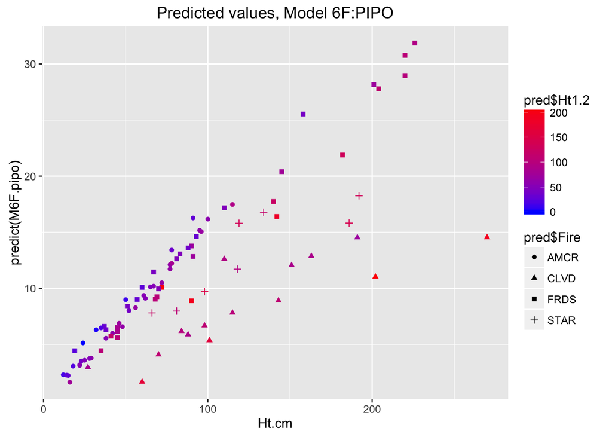

```r
pred <- as.data.frame(predict(M6F.pipo))
pred$Cov <- dfPIPO$Cov1.2
pred$Ht1.2 <- dfPIPO$Ht1.2
pred$Ht.cm <- dfPIPO$Ht.cm
pred$Fire <- dfPIPO$Fire
pred$Grth <- dfPIPO$LastYearGrth.cm
pred$ShrG1 <- dfPIPO$ShrG1
#pred <- arrange(pred, predict(M3.lme))
library(ggplot2)
ggplot(pred)+
  geom_point(aes(y=predict(M6F.pipo),x=Ht.cm,col=pred$Ht1.2, shape=pred$Fire))+
  scale_color_gradient(low="blue",high="red")+
  labs(title = "Predicted values, Model 6F:PIPO")
```

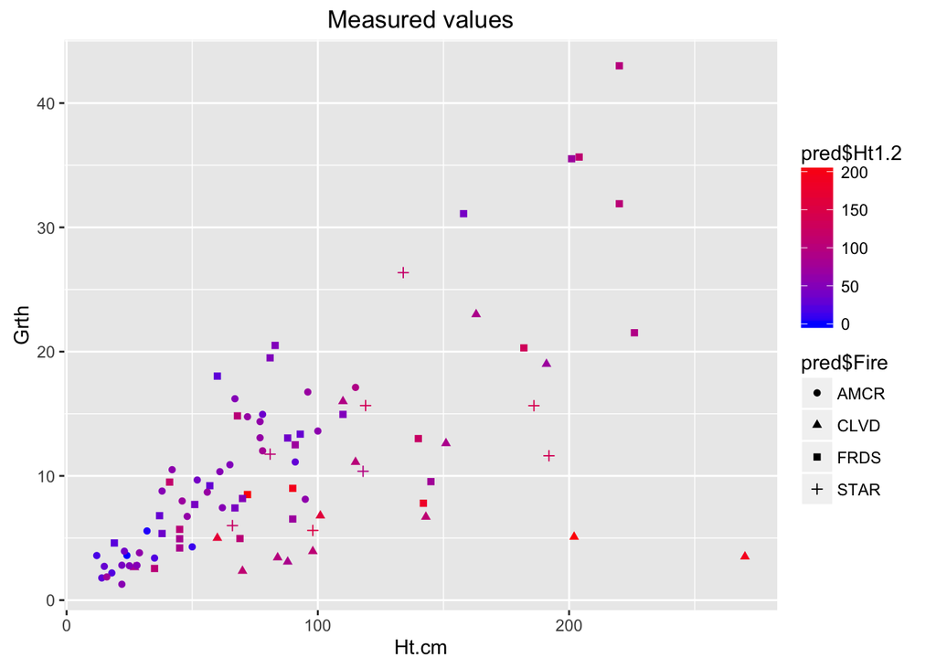

```r
ggplot(pred)+
  geom_point(aes(y=Grth,x=Ht.cm,col=pred$Ht1.2, shape=pred$Fire))+
  scale_color_gradient(low="blue",high="red")+
  labs(title = "Measured values")
```

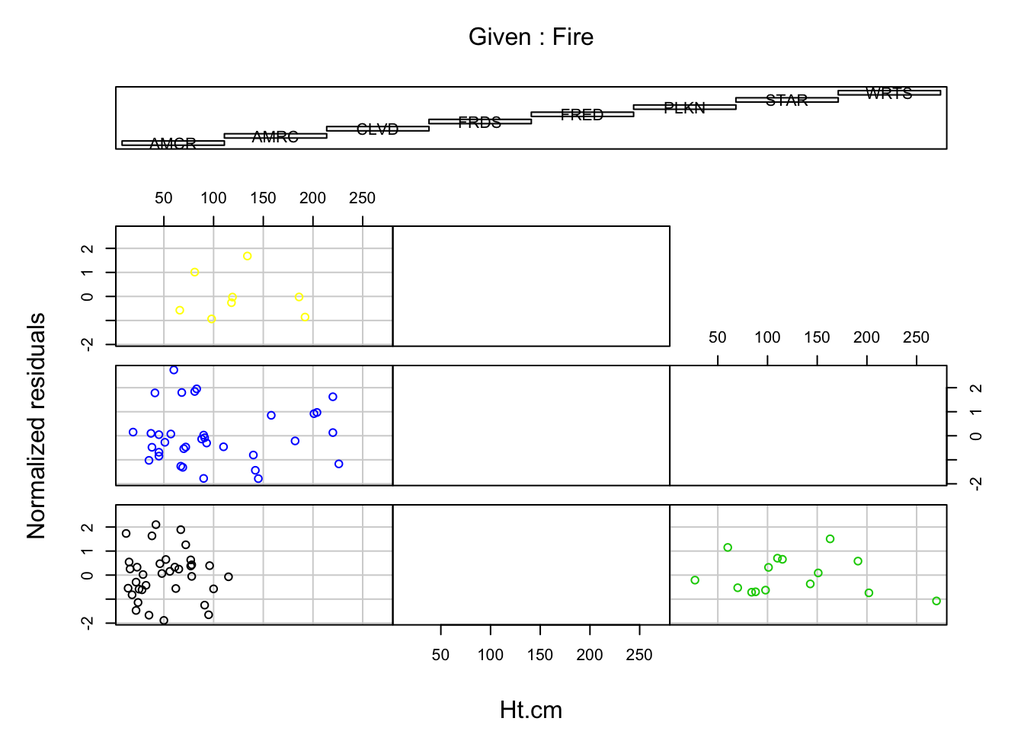

```r
E6F.pipo <- resid(M6F.pipo, type="normalized")
coplot(E6F.pipo ~ Ht.cm | Fire, data=dfPIPO, ylab="Normalized residuals", col=dfPIPO$Fire)
```

- The predicted values and the residuals look good
- Are the different slopes caused by different shrub heights or covers in different patches (ie covariance between fire and shrub heights or covers or shrub species?)

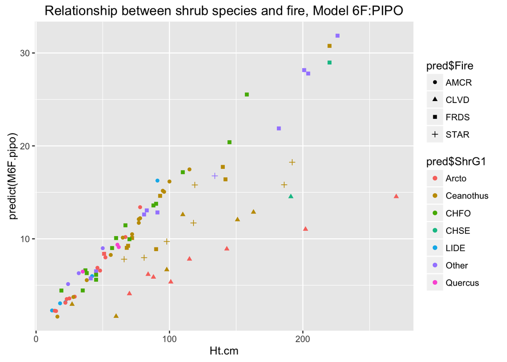

```r
ggplot(pred)+
  geom_point(aes(y=predict(M6F.pipo),x=Ht.cm,col=pred$ShrG1, shape=pred$Fire))+
  labs(title = "Relationship between shrub species and fire, Model 6F:PIPO")
```

- It appears there is a relationship but the shrub species in the flatter-sloped fires are also in other fires
- Potential conclusions from comparing abco and pipo results
  - basal diameter matters for ABCO but not for PIPO
  - shrub cover almost matters for PIPO but not for ABCO
- Try to refine further by using different cover segments and height segments
- Then with all Pinus

**Try out including more/different variables**

```r
M8F.pipo <- gls(LastYearGrth.cm ~ Ht.cm +  BasDia.cm + Cov1.2 + Ht1.2 + Fire + Fire*Ht.cm,
                weights = varPower,
                 data= dfPIPO, method = "ML")
AIC(M8F.pipo)
```

```
## [1] 504.1825
```

```r
M9F.pipo <- gls(LastYearGrth.cm ~ Ht.cm +  BasDia.cm + Ht1.3 + Fire + Fire*Ht.cm,
                weights = varPower,
                 data= dfPIPO, method = "ML")
AIC(M9F.pipo)
```

```
## [1] 503.9347
```

```r
M10F.pipo <- gls(LastYearGrth.cm ~ Ht.cm +  BasDia.cm + Cov1 + Ht1.3 + Fire + Fire*Ht.cm,
                weights = varPower,
                 data= dfPIPO, method = "ML")
AIC(M10F.pipo)
```

```
## [1] 505.5844
```

```r
M11F.pipo <- gls(LastYearGrth.cm ~ Ht.cm +  Cov1 + Ht1.3 + Fire + Fire*Ht.cm,
                weights = varPower,
                 data= dfPIPO, method = "ML")
AIC(M11F.pipo)
```

```
## [1] 507.4909
```

```r
M12F.pipo <- gls(LastYearGrth.cm ~ Ht.cm +  BasDia.cm + Ht1.2 + Fire + Fire*Ht.cm + IAG,
                weights = varPower,
                 data= dfPIPO, method = "ML")
AIC(M12F.pipo)
```

```
## [1] 507.2452
```

```r
M13F.pipo <- gls(LastYearGrth.cm ~ Ht.cm +  BasDia.cm + Ht1.2 + Fire + Fire*Ht.cm + ImmedAboveHt.cm,
                weights = varPower,
                 data= dfPIPO, method = "ML")
AIC(M13F.pipo)
```

```
## [1] 505.1597
```

- now double check that I’m using the best GLS

```r
M6Fa.pipo <- M6F.pipo <- gls(LastYearGrth.cm ~ Ht.cm +  BasDia.cm + Ht1.2 + Fire + Fire*Ht.cm,
                weights = varFixed(~Ht.cm),
                 data= dfPIPO, method = "ML")
AIC(M6Fa.pipo)
```

```
## [1] 509.578
```

```r
M6Fb.pipo <- M6F.pipo <- gls(LastYearGrth.cm ~ Ht.cm +  BasDia.cm + Ht1.2 + Fire + Fire*Ht.cm,
                weights = varExp(form=~ Ht.cm),
                 data= dfPIPO, method = "ML")
AIC(M6Fb.pipo)
```

```
## [1] 512.9183
```

```r
M6Fc.pipo <- M6F.pipo <- gls(LastYearGrth.cm ~ Ht.cm +  BasDia.cm + Ht1.2 + Fire + Fire*Ht.cm,
                weights = varConstPower(form=~Ht.cm),
                 data= dfPIPO, method = "ML")
AIC(M6Fc.pipo)
```

```
## [1] 505.2439
```

```r
# M6F.pipo <- gls(LastYearGrth.cm ~ Ht.cm +  BasDia.cm + Ht1.2 + Fire + Fire*Ht.cm,
#                 weights = varPower,
#                  data= dfPIPO, method = "ML")
# anova(M6F.pipo)
# AIC(M6F.pipo)
#
# M6R.pipo <- gls(LastYearGrth.cm ~ Ht.cm +  BasDia.cm + Ht1.2 + Fire + Fire*Ht.cm,
#                 weights = varPower,
#                 random = ~1|FirePatch,
#                  data= dfPIPO, method = "ML")
# anova(M6F.pipo)
# AIC(M6F.pipo)
```

## Try the same model but with DIFN!

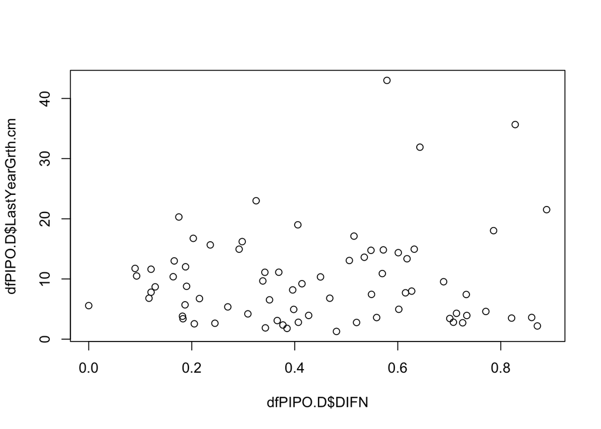

```r
dfPIPO.D <- dfPIPO[!is.na(dfPIPO$DIFN),]
plot(dfPIPO.D$DIFN, dfPIPO.D$LastYearGrth.cm)
```

```r
M1D.pipo <- gls(LastYearGrth.cm ~ Ht.cm +  BasDia.cm + DIFN + Fire + Fire*Ht.cm,
                weights = varPower,
                 data= dfPIPO.D, method = "ML")
AIC(M1D.pipo)
```

```
## [1] 389.5298
```

```r
anova(M1D.pipo)
```

```
## Denom. DF: 63
##             numDF   F-value p-value
## (Intercept)     1 300.20176  <.0001
## Ht.cm           1 130.44581  <.0001
## BasDia.cm       1   0.04966  0.8244
## DIFN            1   0.08196  0.7756
## Fire            3   3.76004  0.0151
## Ht.cm:Fire      3   4.42806  0.0069
```

```r
M2D.pipo <- gls(LastYearGrth.cm ~ Ht.cm +  BasDia.cm + Ht1.2 + Fire + Fire*Ht.cm,
                weights = varPower,
                 data= dfPIPO.D, method = "ML")
AIC(M2D.pipo)
```

```
## [1] 382.7115
```

```r
anova(M2D.pipo)
```

```
## Denom. DF: 63
##             numDF  F-value p-value
## (Intercept)     1 332.4584  <.0001
## Ht.cm           1 141.7841  <.0001
## BasDia.cm       1   0.0255  0.8736
## Ht1.2           1  11.1762  0.0014
## Fire            3   2.0095  0.1216
## Ht.cm:Fire      3   4.7462  0.0048
```

```r
anova(M1D.pipo, M2D.pipo)
```

```
##          Model df      AIC      BIC    logLik
## M1D.pipo     1 12 389.5298 417.0153 -182.7649
## M2D.pipo     2 12 382.7115 410.1970 -179.3557
```

```r
M3D.pipo <- gls(LastYearGrth.cm ~ Ht.cm + Ht1.2 + Fire + Fire*Ht.cm,
                weights = varPower,
                 data= dfPIPO.D, method = "ML")
AIC(M3D.pipo)
```

```
## [1] 380.7167
```

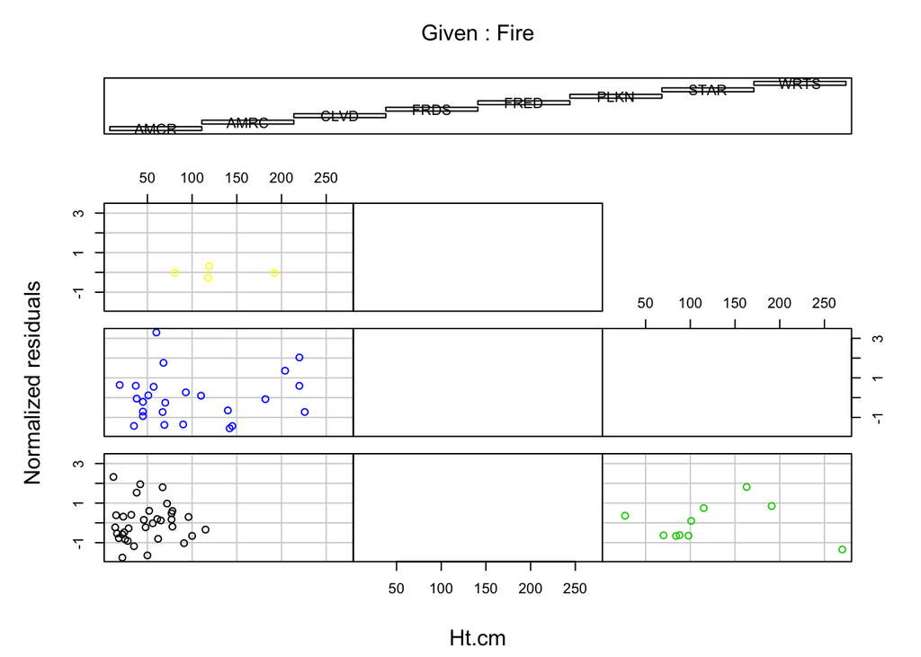

```r
E1D.pipo <- resid(M1D.pipo, type="normalized")
coplot(E1D.pipo ~ Ht.cm | Fire, data=dfPIPO.D, ylab="Normalized residuals", main="DIFN model residuals", col=dfPIPO.D$Fire)
```

```r
M2D.pipo <- lme(LastYearGrth.cm ~ Ht.cm + Ht1 + BasDia.cm,
                random=~1+Ht1|Fire,
                weights = varPower,
                 data= dfPIPO.D,
                method = "ML")
AIC(M2D.pipo)
```

```
## [1] 393.7711
```

```r
anova(M2D.pipo)
```

```
##             numDF denDF  F-value p-value
## (Intercept)     1    66 351.6156  <.0001
## Ht.cm           1    66 163.2680  <.0001
## Ht1             1    66   5.1928  0.0259
## BasDia.cm       1    66   0.3981  0.5303
```

```r
M4D.pipo <- gls(LastYearGrth.cm ~ Ht.cm + + DIFN + Fire + Fire*Ht.cm,
                weights = varPower,
                 data= dfPIPO.D, method = "ML")
AIC(M4D.pipo)
```

```
## [1] 387.9592
```

```r
M5D.pipo <- gls(LastYearGrth.cm ~ Ht.cm + DIFN + Ht1.2 + Fire + Fire*Ht.cm,
                weights = varPower,
                 data= dfPIPO.D, method = "ML")
AIC(M5D.pipo)
```

```
## [1] 382.5041
```

```r
M6D.pipo <- gls(LastYearGrth.cm ~ Ht.cm + DIFN + BasDia.cm + Ht1.2 + Fire + Fire*Ht.cm,
                weights = varPower,
                 data= dfPIPO.D, method = "ML")
AIC(M6D.pipo)
```

```
## [1] 384.4981
```

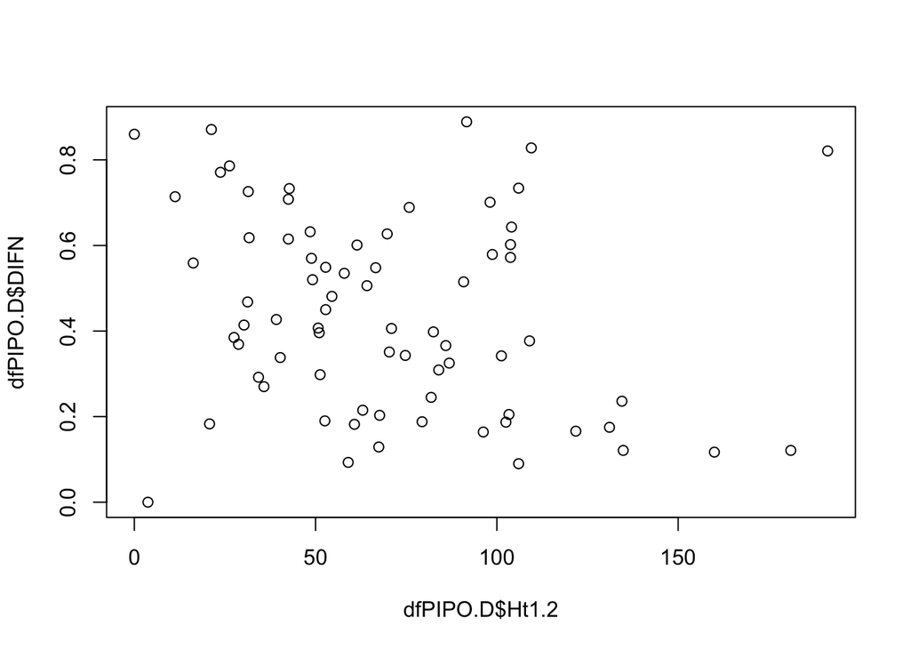

```r
plot(dfPIPO.D$Ht1.2, dfPIPO.D$DIFN)
```

## Main Findings

1. The best model to describe PIPO seedling growth with the data I have is

```r
M6F.pipo <- gls(LastYearGrth.cm ~ Ht.cm +  BasDia.cm + Ht1.2 + Fire + Fire*Ht.cm,
                weights = varPower,
                 data= dfPIPO, method = "ML")
```

2. DIFN is not useful for PIPO
3. Shrub cover is not important but shrub height is
4. Shrub genus does not appear to be important
5. The effect of shrub height on seedling growth is small compared to the effect of seedling height and fire

## Graphically display predictions for a set of fake values

```r
Ht.cm <- c(rep(seq(0,300,5),4))
length(Ht.cm)
```

```
## [1] 244
```

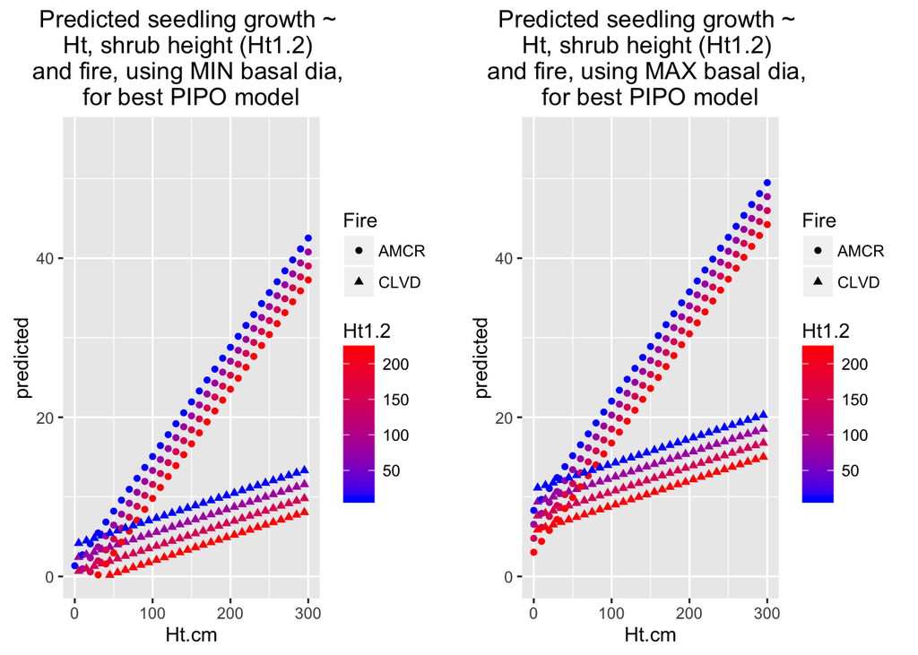

```r
fakedata <- as.data.frame(Ht.cm)
fakedata$BasDia.cm <- c(rep(1,244))
fakedata$Ht1.2 <- c(rep(c(10,80,150,220),61))
fakedata$Fire <- as.factor(c(rep(c("AMCR","CLVD"),30),"AMCR"))
predicted <- predict(M6F.pipo, fakedata)

pred <- as.data.frame(predicted)
pred$Ht1.2 <- fakedata$Ht1.2
pred$Ht.cm <- fakedata$Ht.cm
pred$Fire <- fakedata$Fire
pred$Grth <- fakedata$LastYearGrth.cm

basal1 <- ggplot(pred)+
  geom_point(aes(y= predicted ,x=Ht.cm,col=Ht1.2, shape=Fire))+
  scale_color_gradient(low="blue",high="red")+
  labs(title = "Predicted seedling growth ~ \nHt, shrub height (Ht1.2) \nand fire, using MIN basal dia, \nfor best PIPO model")+
  ylim(0,55)

fakedata$BasDia.cm <- c(rep(7,244))
predicted <- predict(M6F.pipo, fakedata)
pred <- as.data.frame(predicted)
pred$Ht1.2 <- fakedata$Ht1.2
pred$Ht.cm <- fakedata$Ht.cm
pred$Fire <- fakedata$Fire
pred$Grth <- fakedata$LastYearGrth.cm

basal7 <- ggplot(pred)+
  geom_point(aes(y= predicted ,x=Ht.cm,col=Ht1.2, shape=Fire))+
  scale_color_gradient(low="blue",high="red")+
  labs(title = "Predicted seedling growth ~ \nHt, shrub height (Ht1.2) \nand fire, using MAX basal dia, \nfor best PIPO model")+
  ylim(0,55)

require(gridExtra)
grid.arrange(basal1, basal7,ncol=2)
```